# Testing the hierarchical reserving models on the simulation engine including recoveries

## Evaluating the predictive performance of the chain-ladder model and the hierarchical GLM and GBM

First, we compare the prediction for the total number of open claims in the test set.

```r
nsim <- 50

# Predictions
obs_open_total <- prediction_data %>% filter(calendar.year != 10) %>% summarise(Total = sum(open)) %>% pull(Total)
cl_open_total  <- sum(cl_open)
glm_open_total <- simul_glm %>% filter(calendar.year != 10) %>% summarise(Total = sum(open)/nsim) %>% pull(Total)
gbm_open_total <- simul_gbm %>% filter(calendar.year != 10) %>% summarise(Total = sum(open)/nsim) %>% pull(Total)
cann_open_total <- simul_cann %>% filter(calendar.year != 10) %>% summarise(Total = sum(open)/nsim) %>% pull(Total)
cann2_open_total <- simul_cann2 %>% filter(calendar.year != 10) %>% summarise(Total = sum(open)/nsim) %>% pull(Total)

# Print Results
c('Actual' =  obs_open_total,
  'Chain-Ladder' = cl_open_total,
  'Hierarchical GLM' = glm_open_total,
  'Hierarchical GBM' = gbm_open_total,
  'Hierarchical CANN/GLM' = cann_open_total,
  'Hierarchical CANN/GBM' = cann2_open_total
  )
```

```
##                Actual          Chain-Ladder      Hierarchical GLM      Hierarchical GBM Hierarchical CANN/GLM Hierarchical CANN/GBM
##              51395.00              51237.38              51187.30              50811.02              51225.38              51282.36
```

Second, we compare the prediction for the total number of payments in the prediction data set.

```r
# Predictions
obs_pay_total <- prediction_data %>% summarise(Total = sum(payment)) %>% pull(Total)
cl_pay_total  <- sum(cl_pay)
glm_pay_total <- simul_glm %>% summarise(Total = sum(payment)/nsim) %>% pull(Total)
gbm_pay_total <- simul_gbm %>% summarise(Total = sum(payment)/nsim) %>% pull(Total)
cann_pay_total <- simul_cann %>% summarise(Total = sum(payment)/nsim) %>% pull(Total)
cann2_pay_total <- simul_cann2 %>% summarise(Total = sum(payment)/nsim) %>% pull(Total)

# Print Results
c('Actual' = obs_pay_total,
  'Chain-Ladder' = cl_pay_total,
  'Hierarchical GLM' = glm_pay_total,
  'Hierarchical GBM' = gbm_pay_total,
  'Hierarchical CANN/GLM' = cann_pay_total,
  'Hierarchical CANN/GBM' = cann2_pay_total
  )
```

```
##                Actual          Chain-Ladder      Hierarchical GLM      Hierarchical GBM Hierarchical CANN/GLM Hierarchical CANN/GBM
##              49842.00              50090.20              49962.44              49824.42              50041.26              50083.22
```

Third, we compare the prediction for the total number of recoveries in the prediction data set.

```r
# Predictions
obs_recov_total <- prediction_data %>% summarise(Total = sum(recovery)) %>% pull(Total)

glm_recov_total <- simul_glm %>% summarise(Total = sum(recovery)/nsim) %>% pull(Total)
gbm_recov_total <- simul_gbm %>% summarise(Total = sum(recovery)/nsim) %>% pull(Total)
cann_recov_total <- simul_cann %>% summarise(Total = sum(recovery)/nsim) %>% pull(Total)
cann2_recov_total <- simul_cann2 %>% summarise(Total = sum(recovery)/nsim) %>% pull(Total)

# Print Results
c('Actual' = obs_recov_total,
  'Hierarchical GLM' = glm_recov_total,
  'Hierarchical GBM' = gbm_recov_total,
  'Hierarchical CANN/GLM' = cann_recov_total,
  'Hierarchical CANN/GBM' = cann2_recov_total
  )
```

```
##                Actual      Hierarchical GLM      Hierarchical GBM Hierarchical CANN/GLM Hierarchical CANN/GBM
##               9183.00               9108.86               8978.84               9131.34               9118.10
```

Fourth, we compare the prediction for the total number of payment sizes in the prediction set.

```r
# Predictions
obs_size_pay_total <- prediction_data %>% summarise(Total = sum(size.pay)) %>% pull(Total)
cl_size_pay_total  <- sum(cl_size_pay)
glm_size_pay_total <- simul_glm %>% summarise(Total = sum(size.pay)/nsim) %>% pull(Total)
gbm_size_pay_total <- simul_gbm %>% summarise(Total = sum(size.pay)/nsim) %>% pull(Total)
cann_size_pay_total <- simul_cann %>% summarise(Total = sum(size.pay)/nsim) %>% pull(Total)
cann2_size_pay_total <- simul_cann2 %>% summarise(Total = sum(size.pay)/nsim) %>% pull(Total)

# Print Results
c('Actual' = obs_size_pay_total,
  'Chain-Ladder' = cl_size_pay_total,
  'Hierarchical GLM' = glm_size_pay_total,
  'Hierarchical GBM' = gbm_size_pay_total,
  'Hierarchical CANN/GLM' = cann_size_pay_total,
  'Hierarchical CANN/GBM' = cann2_size_pay_total
  )
```

```
##                Actual          Chain-Ladder      Hierarchical GLM      Hierarchical GBM Hierarchical CANN/GLM Hierarchical CANN/GBM
##              62774208              63488322              63299150              62706276              63556899              63627283
```

Fifth, we compare the prediction for the total amount of recovery sizes in the prediction set.

```r
update_simul <- function(simul) {

  simul <- simul %>%
    dplyr::select(-p.size.recov, -size.recov) %>%
    dplyr::group_by(simulation, claim.nr) %>%
    dplyr::mutate(total.size.pay = sum(size.pay)) %>%
    dplyr::ungroup() %>%
    dplyr::mutate(p.size.recov = exp(q.size.recov) / (1+exp(q.size.recov)),
                  size.recov = p.size.recov * total.size.pay)

  return(simul)

}

simul_glm <- update_simul(simul_glm)
simul_gbm <- update_simul(simul_gbm)
simul_cann <- update_simul(simul_cann)
simul_cann2 <- update_simul(simul_cann2)

# Predictions
obs_size_recov_total <- prediction_data %>% summarise(Total = sum(size.recov)) %>% pull(Total)
cl_size_recov_total  <- sum(cl_size_recov, na.rm=T)
glm_size_recov_total <- simul_glm %>% filter(recovery==1) %>% summarise(Total = sum(size.recov)/nsim) %>% pull(Total)
gbm_size_recov_total <- simul_gbm %>% filter(recovery==1) %>% summarise(Total = sum(size.recov)/nsim) %>% pull(Total)
cann_size_recov_total <- simul_cann %>% filter(recovery==1) %>% summarise(Total = sum(size.recov)/nsim) %>% pull(Total)
cann2_size_recov_total <- simul_cann2 %>% filter(recovery==1) %>% summarise(Total = sum(size.recov)/nsim) %>% pull(Total)

# Print Results
c('Actual' = obs_size_recov_total,
  'Chain-Ladder' = cl_size_recov_total,
  'Hierarchical GLM' = glm_size_recov_total,
  'Hierarchical GBM' = gbm_size_recov_total,
  'Hierarchical CANN/GLM' = cann_size_recov_total,
  'Hierarchical CANN/GBM' = cann2_size_recov_total
  )
```

```
##                Actual          Chain-Ladder      Hierarchical GLM      Hierarchical GBM Hierarchical CANN/GLM Hierarchical CANN/GBM
##               7475004               6243083               6360219               6393871               6399787               6359830
```

```r
obs_size_total <- prediction_data %>% summarise(Total = sum(size)) %>% pull(Total)
# Print Results
c('Actual' = obs_size_total,
  'Chain-Ladder' = cl_size_pay_total - cl_size_recov_total,
  'Hierarchical GLM' = glm_size_pay_total - glm_size_recov_total,
  'Hierarchical GBM' = gbm_size_pay_total - gbm_size_recov_total,
  'Hierarchical CANN/GLM' = cann_size_pay_total - cann_size_recov_total,
  'Hierarchical CANN/GBM' = cann2_size_pay_total - cann2_size_recov_total
  )
```

```
##                Actual          Chain-Ladder      Hierarchical GLM      Hierarchical GBM Hierarchical CANN/GLM Hierarchical CANN/GBM
##              55299205              57245239              56938930              56312406              57157113              57267453
```

Comparing the empirical cumulative distribution function obtained from the prediction dataset with the one obtained from the simulated data:

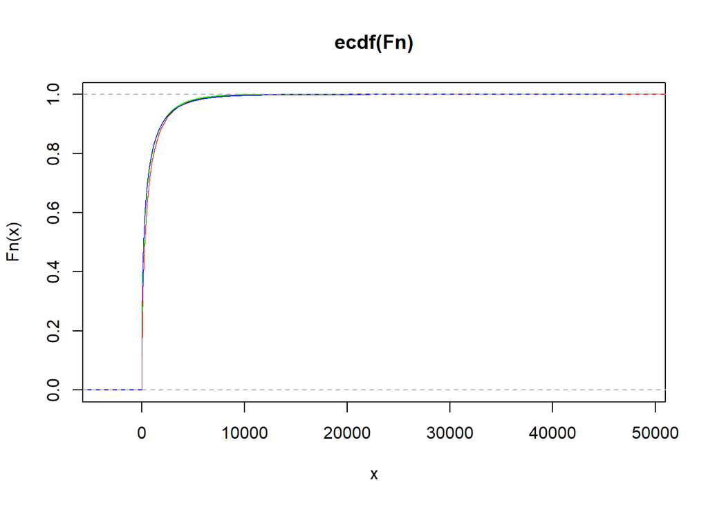

```r
Fn <- prediction_data %>% filter(size.recov > 0) %>% pull(size.recov)
ecdf_pred <- ecdf(Fn)
plot(ecdf_pred, do.points = F, col.hor = "red")
ecdf_glm <- ecdf(simul_glm %>% filter(recovery==1) %>% pull(size.recov))
lines(ecdf_glm, do.points = F, col.hor = "green")
ecdf_gbm <- ecdf(simul_gbm %>% filter(recovery==1) %>% pull(size.recov))
lines(ecdf_gbm, do.points = F, col.hor = "blue")
```

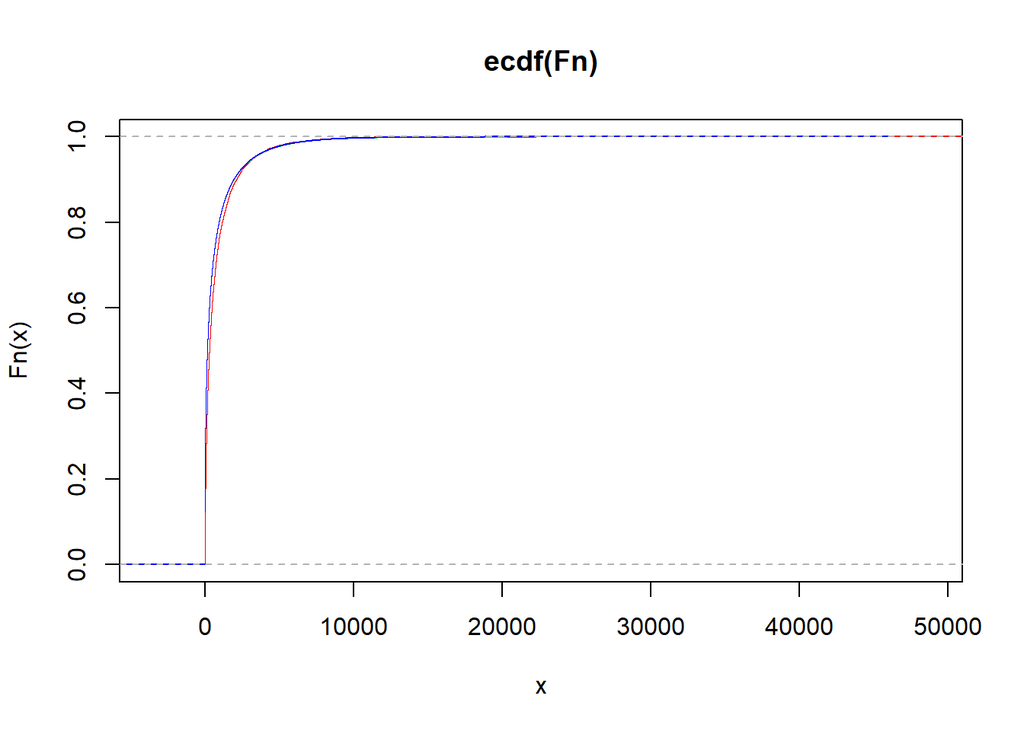

```r
Fn <- prediction_data %>% filter(size.recov > 0) %>% pull(size.recov)
ecdf_pred <- ecdf(Fn)
plot(ecdf_pred, do.points = F, col.hor = "red")
ecdf_cann <- ecdf(simul_cann %>% filter(recovery==1) %>% pull(size.recov))
lines(ecdf_cann, do.points = F, col.hor = "green")
ecdf_cann2 <- ecdf(simul_cann2 %>% filter(recovery==1) %>% pull(size.recov))
lines(ecdf_cann2, do.points = F, col.hor = "blue")
```

## References

Creveceour, Jonas, Katrien Antonio, and Jens Robben. 2021. “A Hierarchical Reserving Model for Reported Non-Life Insurance Claims.”